# LAB4

```r
#hacemos lo mismo con la función replicate()
replicate(10000, tarjetas_binom)
```

[output not shown]

[output cut: 263 more lines]

3. Considerar el efecto de sumar dos distribuciones normales, una de media = 3 y desviación estándar = 2 y otra con media = 5 y desviación estándar = 3.

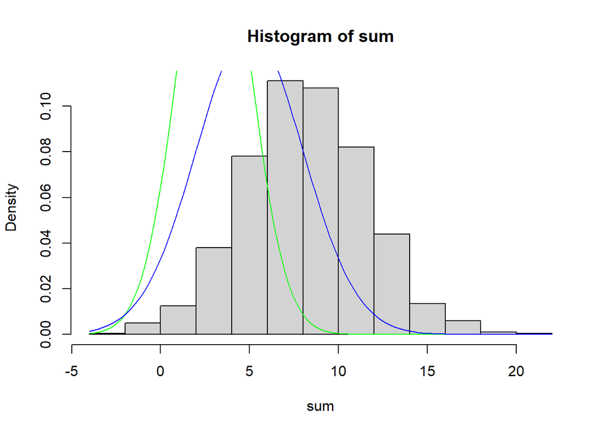

```r
#generamos las distribuciónes
dist_1 <- rnorm(1000,3,2)
dist_2 <- rnorm(1000,5, 3)

sum <- dist_1 + dist_2
{hist(sum, freq = F)
  curve(dnorm(x,3,2), add=T, col="green")
  curve(dnorm(x,5,3), add=T, col="blue")
}
```

EJERCICIO 8. R-COMMANDER Dada una distribución N(μ,σ2) ~ N(20,9)

library(“Rcmdr”) #inicializamos R commander

EJERCICIO 9. Resolved los siguientes ejercicios utilizando Rstudio y RCommander y comentad los resultados obtenidos:

1. Se ha realizado un estudio a partir del cual se sabe que un determinado fármaco reduce los efectos de la alergia al polen. Con los datos obtenidos hasta el momento, solo en el 4 % de los casos no ha surgido efecto.

– ¿Qué tipo de distribución representa este caso?

```r
#presenta una distribución binomial, esta formada por un nº predeterminado de n
#experimentos iguales independientes entre si. El resultado de cada experimento
#admite solo dos categorias
```

– ¿Cuál es la probabilidad de que si se realiza la técnica 100 veces haya más de 5 casos en los que el fármaco no sea efectivo?

```r
pbinom(c(5),100,0.04)
```

```
## [1] 0.7883749
```

- Representad en un diagrama de puntos la distribución que represente la probabilidad de que, si se realiza la técnica 80 casos, haya exactamente 4 rechazos.

```r
dbinom(0:4,80,0.04)
```

```
## [1] 0.03816793 0.12722644 0.20939352 0.22684298 0.18194698
```

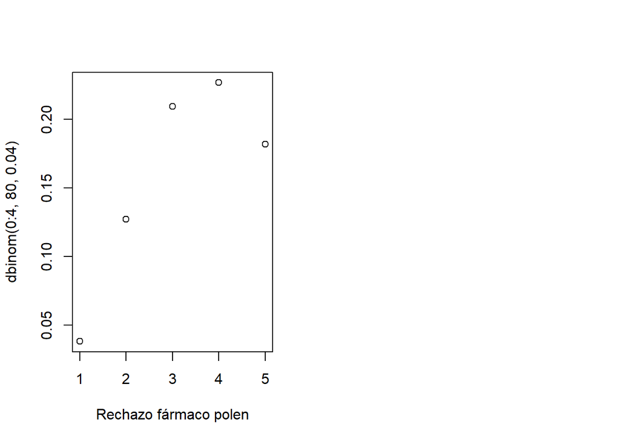

```r
#representamos la distribución
par(mfrow=c(1,2))
plot(dbinom(0:4,80,0.04),xlab = "Rechazo fármaco polen")
```

2. La duración media de recuperación de una gripe común es de 7 ± 2 días (media y desviación estándar). Suponiendo que se trata de una distribución normal, calculad la probabilidad de que la recuperación dure entre 6 y 10 días.

```r
pnorm(10,7,2)-pnorm(6,7,2)
```

```
## [1] 0.6246553
```

EJERCICIO FINAL ACUMULATIVO. En este ejercicio estudiaremos la distribución de unos datos unidimensionales. Los datos que usaremos son el dataset Faithful incorporado en las librerías de R. Este dataset nos da información sobre el tiempo de espera entre erupciones y la duración de la erupción del Géiser Old Faithful en el Parque Nacional de

Yellowstone, Wyoming, Estados Unidos (https://stat.ethz.ch/R- manual/Rdevel/library/datasets/html/faithful.html).

1. Realizad un estudio estadístico descriptivo de la variable eruptions y generad el gráfico de tallo y hojas.

```r
library(MASS)
data("faithful")
attach(faithful)

#El resumen estadistico
summary(eruptions)
```

```
##    Min. 1st Qu.  Median    Mean 3rd Qu.    Max.
##   1.600   2.163   4.000   3.488   4.454   5.100
```

```r
#o
fivenum(eruptions)
```

```
## [1] 1.6000 2.1585 4.0000 4.4585 5.1000
```

```r
names(faithful)
```

```
## [1] "eruptions" "waiting"
```

```r
stem(eruptions)
```

```
##
##   The decimal point is 1 digit(s) to the left of the |
##
##   16 | 070355555588
##   18 | 000022233333335577777777888822335777888
##   20 | 00002223378800035778
##   22 | 0002335578023578
##   24 | 00228
##   26 | 23
##   28 | 080
##   30 | 7
##   32 | 2337
##   34 | 250077
##   36 | 0000823577
##   38 | 2333335582225577
##   40 | 0000003357788888002233555577778
##   42 | 03335555778800233333555577778
##   44 | 02222335557780000000023333357778888
##   46 | 0000233357700000023578
##   48 | 00000022335800333
##   50 | 0370
```

2. Generad el histograma. Definid intervalos menores en el histograma y añadid al gráfico la función de densidad superpuesta.

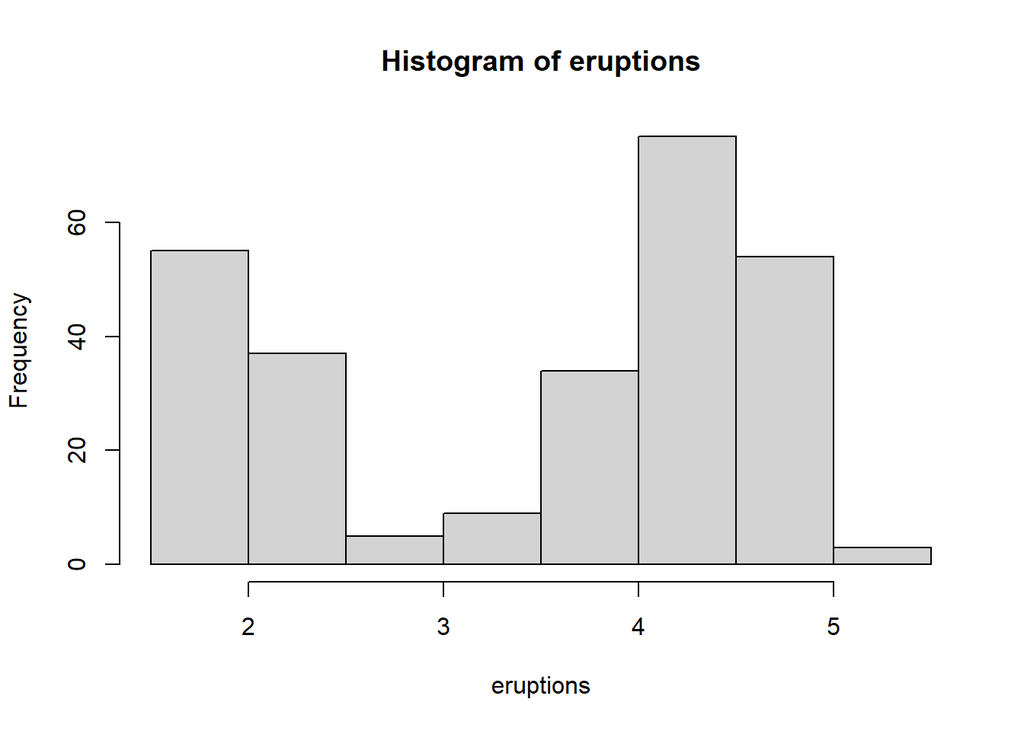

```r
hist(eruptions)
```

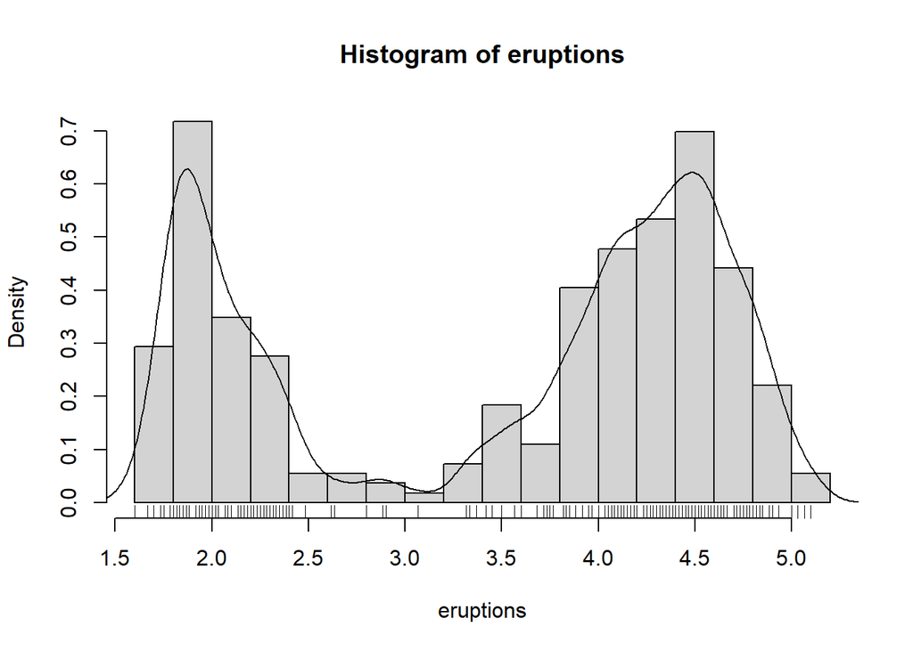

```r
#definimos intervalor menores y añadimos un grafco de densidad
hist(eruptions, seq(1.6, 5.2, 0.2), prob=TRUE)
lines(density(eruptions, bw=0.1))
rug(eruptions) #para ver la localización exacta de los puntos
```

3. Usando la función ecdf de la biblioteca estándar stepfun, representad la función de distribución empírica de la muestra, es decir, una distribución a partir de estos datos que proporcione un cierto parecido a una distribución verdadera asociada con la población.

```r
library(tidyverse)
```

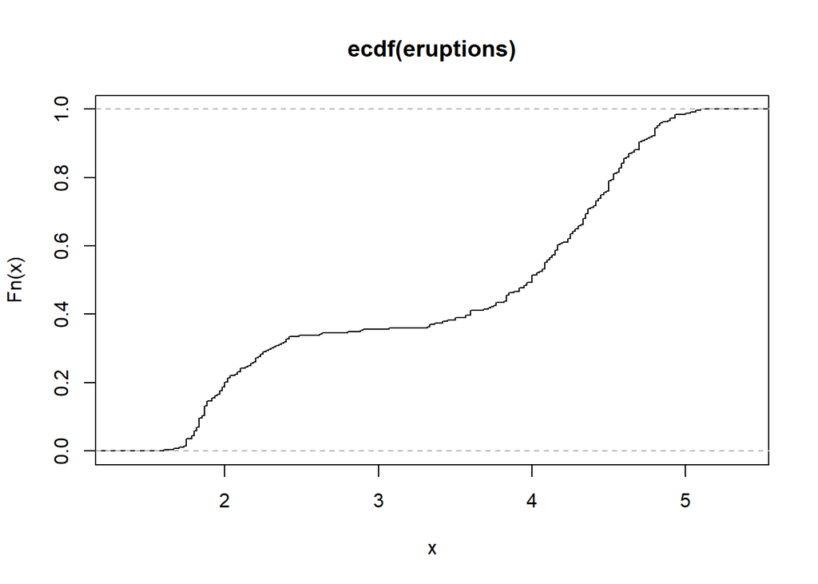

```r
plot(ecdf(eruptions), do.points=FALSE, verticals=TRUE)
```

4. ¿Creéis que la distribución del apartado anterior corresponde a alguna distribución estándar conocida?

```r
#A una distribución estándar conocida no. Podemos decir que es una distribución
#acumulada y quizás una bimodal.
```

5. Seleccionad las erupciones que duran más de 3 minutos. ¿Qué podéis decir de estos datos? ¿Creéis que se parecen a alguna distribución?

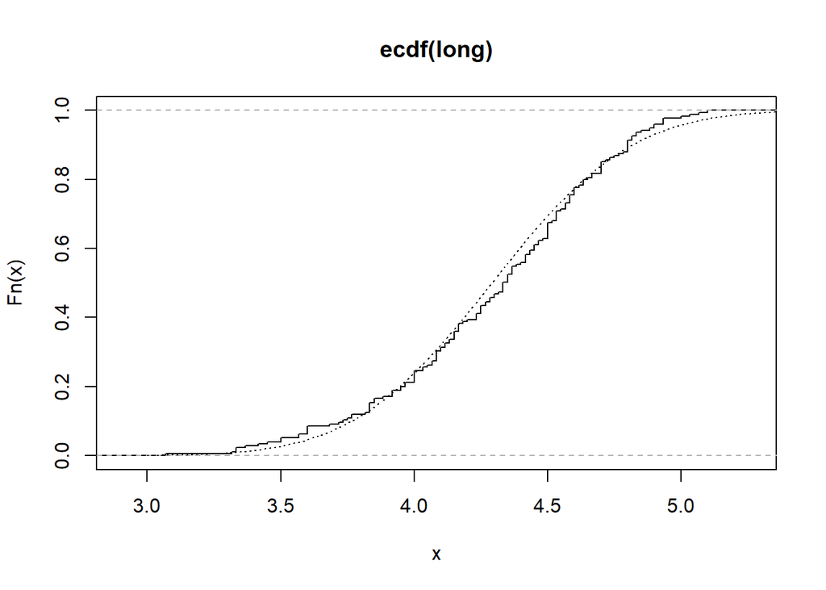

```r
long<-eruptions [eruptions >3]
plot(ecdf(long), do.points=FALSE, verticals=TRUE)

x<-seq(3, 5.4, 0.01)
lines(x, pnorm(x, mean=mean(long), sd=sqrt(var(long))), lty=3)
```